# Stephen Strasburg and The Birth of the Nationals

## Introduction

Let me tell you a story, of a man who brought hope, joy, and glory to a city devoid of such those feelings for far too long. However, I must first set the stage before the show can begin. As [America's national pastime](https://bleacherreport.com/articles/676720-americas-pastime-20-reasons-why-baseball-will-always-hail-over-football), and my personal favorite sport, baseball has warmed the hearts and brought tears to the eyes for millions for over a century. Despite this, the unfortunate decision was made in 1971 to move the national pastime away from our nation's capital, when the Washington Senators relocated and becamethe Texas Rangers. For the next 34 years, D.C. remained dormant during the summer, fans waiting and praying that their beloved team would return. This day came in 2004 when the Montreal Expos financial failures pushed them to make a move to D.C., and the team known as the [Washington Nationals were born](https://en.wikipedia.org/wiki/History_of_the_Washington_Nationals#Montreal_Expos).

Jacob Yank

## Part 1: Early Failures

We begin by importing the necessary Python packages,pandas and numpy, to help us load and explore our data.

The data I am using comes from [Sean Lahman](https://www.seanlahman.com/baseball-archive/statistics/), the same dataset used in Project 2, and it contains all team, hitting, and pitching statisfics spanning the entire history of baseball.

Having downloaded the necesary CSV files, the first table we grab contains data for every team accorss every year, and this is done with the Pandas read_csv function.

```python
import pandas as pd
import numpy as np
teams = pd.read_csv('Teams.csv')
teams.head()
```

|  | yearID | lgID | teamID | franchID | divID | Rank | G | Ghome | W | L | ... | DP | FP | name | park | attendance | BPF | PPF | teamIDBR | teamIDlahman45 | teamIDretro |
| --- | --- | --- | --- | --- | --- | --- | --- | --- | --- | --- | --- | --- | --- | --- | --- | --- | --- | --- | --- | --- | --- |
| 0 | 1871 | NaN | BS1 | BNA | NaN | 3 | 31 | NaN | 20 | 10 | ... | 24 | 0.834 | Boston Red Stockings | South End Grounds I | NaN | 103 | 98 | BOS | BS1 | BS1 |
| 1 | 1871 | NaN | CH1 | CNA | NaN | 2 | 28 | NaN | 19 | 9 | ... | 16 | 0.829 | Chicago White Stockings | Union Base-Ball Grounds | NaN | 104 | 102 | CHI | CH1 | CH1 |
| 2 | 1871 | NaN | CL1 | CFC | NaN | 8 | 29 | NaN | 10 | 19 | ... | 15 | 0.818 | Cleveland Forest Citys | National Association Grounds | NaN | 96 | 100 | CLE | CL1 | CL1 |
| 3 | 1871 | NaN | FW1 | KEK | NaN | 7 | 19 | NaN | 7 | 12 | ... | 8 | 0.803 | Fort Wayne Kekiongas | Hamilton Field | NaN | 101 | 107 | KEK | FW1 | FW1 |
| 4 | 1871 | NaN | NY2 | NNA | NaN | 5 | 33 | NaN | 16 | 17 | ... | 14 | 0.840 | New York Mutuals | Union Grounds (Brooklyn) | NaN | 90 | 88 | NYU | NY2 | NY2 |

5 rows × 48 columns

The first piece I would like to highlight is truly how rough the Nationals first couple of seasons were. To do so, I begin by restricting the years to 2005-2009, and I group each team together accross that time span.

```python
mid_2000s_all = teams[(teams['yearID'] > 2004) & (teams['yearID'] < 2010)]
mid_2000s = mid_2000s_all.groupby('teamID').mean()
mid_2000s.head()
```

| teamID | yearID | Rank | G | Ghome | W | L | R | AB | H | 2B | ... | HA | HRA | BBA | SOA | E | DP | FP | attendance | BPF | PPF |
| --- | --- | --- | --- | --- | --- | --- | --- | --- | --- | --- | --- | --- | --- | --- | --- | --- | --- | --- | --- | --- | --- |
| ARI | 2007.0 | 2.8 | 162.0 | 81.0 | 79.0 | 83.0 | 724.2 | 5513.4 | 1407.6 | 306.6 | ... | 1480.4 | 169.0 | 519.0 | 1125.6 | 108.2 | 151.6 | 0.9824 | 2223009.4 | 105.6 | 106.2 |
| ATL | 2007.0 | 2.8 | 162.0 | 81.0 | 82.2 | 79.8 | 783.2 | 5580.2 | 1499.6 | 312.8 | ... | 1459.2 | 155.0 | 549.0 | 1078.4 | 99.0 | 153.0 | 0.9842 | 2544672.6 | 99.2 | 98.6 |
| BAL | 2007.0 | 4.4 | 161.8 | 81.0 | 69.0 | 92.8 | 755.2 | 5593.8 | 1514.2 | 303.8 | ... | 1539.8 | 191.8 | 624.4 | 1002.0 | 95.6 | 155.8 | 0.9840 | 2159987.8 | 100.2 | 101.0 |
| BOS | 2007.0 | 2.0 | 162.0 | 81.0 | 93.4 | 68.6 | 862.8 | 5594.6 | 1542.0 | 341.2 | ... | 1466.6 | 162.0 | 501.8 | 1118.6 | 84.6 | 144.8 | 0.9858 | 2972036.0 | 105.8 | 104.8 |
| CHA | 2007.0 | 2.4 | 162.2 | 81.2 | 85.8 | 76.4 | 767.4 | 5528.6 | 1449.0 | 267.0 | ... | 1478.2 | 173.2 | 471.6 | 1066.6 | 102.6 | 158.4 | 0.9832 | 2553890.6 | 104.2 | 104.2 |

5 rows × 35 columns

In order to demonstrate how poor these first few seasons were, I have graphed each teams mean number of wins against their mean total home attendance from 2005-2009. We can clearly see that that the Nats(WAS) had the third lowest average number of wins per season, but did rather well in terms of attendance, especially based on the on field performance. This is evidenced by their placement above the line of best fit.

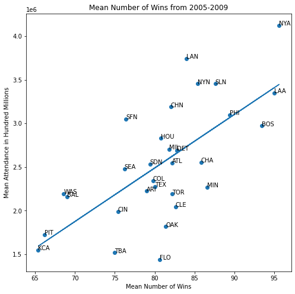

```python
from matplotlib import pyplot as plt
fig, ax = plt.subplots(figsize=(8,8))
ax.set_xlabel('Mean Number of Wins')
ax.set_ylabel('Mean Attendance in Hundred Millions')
ax.set_title('Mean Number of Wins from 2005-2009')
ax.scatter(mid_2000s['W'], mid_2000s['attendance'])
for k, v in mid_2000s.iterrows():
    ax.annotate(k, (v['W'], v['attendance']))
a, b = np.polyfit(mid_2000s['W'], mid_2000s['attendance'],1)
plt.plot(mid_2000s['W'],a*mid_2000s['W']+b)
```

However, this seemingly high attendance is carried by two unique seasons. In order to construct the table below, we pull the Nats out of our mid 2000s table, and display the desired information. There are two standout years, 2005 and 2008. The former was the teams innaugural season, and they recorded by far the highest attendance out of the 5 years. The latter was the opening of the teams new ballpark, Nationals Park, which clearly drew people to stadium, evidenced by the increase from 2007 despite being a worse team overall.

```python
nationals_mid_2k = mid_2000s_all[mid_2000s_all['teamID'] == 'WAS']
nationals_mid_2k[['teamID', 'yearID', 'park', 'attendance', 'W']]
```

|  | teamID | yearID | park | attendance | W |
| --- | --- | --- | --- | --- | --- |
| 2504 | WAS | 2005 | R.F.K. Stadium | 2731993.0 | 81 |
| 2534 | WAS | 2006 | R.F.K. Stadium | 2153056.0 | 71 |
| 2564 | WAS | 2007 | R.F.K. Stadium | 1943812.0 | 73 |
| 2594 | WAS | 2008 | Nationals Park | 2320400.0 | 59 |
| 2624 | WAS | 2009 | Nationals Park | 1817226.0 | 59 |

## Part 2: Merry Strasmas!

After 59 wins in the 2008 season, the Nationals were the worst team in baseball, and were awarded the number one pick on the 2009 MLB Draft. As I spoiled it earlier, you know who they took, and immediately the hype machine began to build. Strasburg’s 2010 debut with the Harrisburg Senators, the Nationals AA Minor League affiliate (the minor leagues are a developmental set of leagues where teams train their prospects before bringing them up to the majors), [drew over 70 credentialed media members](https://www.washingtonpost.com/wp-dyn/content/article/2010/06/17/AR2010061705517_pf.html) and ESPN nationally broadcast portions of the game.

My 9 year old self could not contain my excitement. Finally, my hometown team had some hope, and when news came that Strasburg would be making his major-league debut on June 8th of that year, I pleaded with my dad to take us. A burgeoning fan himself, he agreed, and on that day, at the nosiest of nose bleeds, we experienced the most electrifying performance of our lives.

[“Strasmas” was born](http://sports.espn.go.com/mlb/news/story?id=5261829). Except, it didn’t only come one a year, but rather every fifth day. Finally, after half a decade, there was hope. As seen above, the Nats went on to win 59 games again in 2009, and were awarded another number one overall draft pick. In the 2010 Draft they selected Bryce Harper, [the greatest baseball prospect ever, period](https://www.si.com/vault/2009/06/08/105822135/baseballs-lebron). He could have a whole project dedicated to him, but it was with Strasburg that this turn around really began.

## Part 3: Let the Good Times Roll

Now things were starting to fall into place, and because they had stunk for so long, young talent had continuously been accumulating. Finally, in 2012 it clicked, and [the Nats shocked the baseball world](https://www.federalbaseball.com/2012/12/31/3820126/washington-nationals-top-5-stories-of-2012-no-1-nats-clinch-nl-east) en route to the best record in the Major Leagues.

The next table we take a look at contains team data from 2012-2019, aptly named glory_years, as you will soon see.

```python
glory_years = teams[(teams['yearID'] > 2011) & (teams['yearID'] < 2020)]
glory_years.head()
```

|  | yearID | lgID | teamID | franchID | divID | Rank | G | Ghome | W | L | ... | DP | FP | name | park | attendance | BPF | PPF | teamIDBR | teamIDlahman45 | teamIDretro |
| --- | --- | --- | --- | --- | --- | --- | --- | --- | --- | --- | --- | --- | --- | --- | --- | --- | --- | --- | --- | --- | --- |
| 2685 | 2012 | NL | ARI | ARI | W | 3 | 162 | 81.0 | 81 | 81 | ... | 146 | 0.985 | Arizona Diamondbacks | Chase Field | 2177617.0 | 105 | 106 | ARI | ARI | ARI |
| 2686 | 2012 | NL | ATL | ATL | E | 2 | 162 | 81.0 | 94 | 68 | ... | 147 | 0.986 | Atlanta Braves | Turner Field | 2420171.0 | 102 | 101 | ATL | ATL | ATL |
| 2687 | 2012 | AL | BAL | BAL | E | 2 | 162 | 81.0 | 93 | 69 | ... | 151 | 0.983 | Baltimore Orioles | Oriole Park at Camden Yards | 2102240.0 | 102 | 103 | BAL | BAL | BAL |
| 2688 | 2012 | AL | BOS | BOS | E | 5 | 162 | 81.0 | 69 | 93 | ... | 159 | 0.983 | Boston Red Sox | Fenway Park II | 3043003.0 | 106 | 106 | BOS | BOS | BOS |
| 2689 | 2012 | AL | CHA | CHW | C | 2 | 162 | 81.0 | 85 | 77 | ... | 154 | 0.988 | Chicago White Sox | U.S. Cellular Field | 1965955.0 | 106 | 106 | CHW | CHA | CHA |

5 rows × 48 columns

Lets take a look at that same graph we saw earlier. Well now, this is a different picture. Stuck somewhere in no mans land the Nats had the second highest mean number of wins per season, but fell way short of their expected attendance numbers. Which I must admit surprised me.

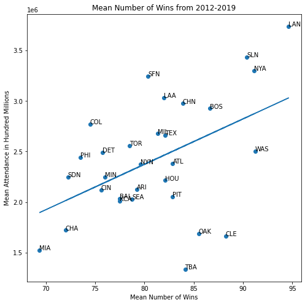

```python
mid_2010s = glory_years.groupby('teamID').mean()
fig, ax = plt.subplots(figsize=(8,8))
ax.set_xlabel('Mean Number of Wins')
ax.set_ylabel('Mean Attendance in Hundred Millions')
ax.set_title('Mean Number of Wins from 2012-2019')
ax.scatter(mid_2010s['W'], mid_2010s['attendance'])
for k, v in mid_2010s.iterrows():
    ax.annotate(k, (v['W'], v['attendance']))
a, b = np.polyfit(mid_2010s['W'], mid_2010s['attendance'],1)
plt.plot(mid_2010s['W'],a*mid_2010s['W']+b)
```

It's close between the Yankees and Nationals on the graph, so lets just make sure. Even if it's a tenth of a win a season, its more.

```python
mid_2010s['W'].sort_values(ascending=False).head()
```

```
teamID
LAN    94.625
WAS    91.250
NYA    91.125
SLN    90.375
CLE    88.250
Name: W, dtype: float64
```

Just something to note, while the Nats had less attendance than expected based on their wins, the attendance accross the league was down, as seen below

```python
mid_2000s['attendance'].mean()/81
```

```
31481.381316872434
```

```python
mid_2010s['attendance'].mean()/81
```

```
29852.91774691358
```

While the team around him shined, so did Stephen. First we read in a table containing all the pitching data accross MLB history.

```python
pitching_data = pd.read_csv('Pitching.csv')
pitching_data.head()
```

|  | playerID | yearID | stint | teamID | lgID | W | L | G | GS | CG | ... | IBB | WP | HBP | BK | BFP | GF | R | SH | SF | GIDP |
| --- | --- | --- | --- | --- | --- | --- | --- | --- | --- | --- | --- | --- | --- | --- | --- | --- | --- | --- | --- | --- | --- |
| 0 | bechtge01 | 1871 | 1 | PH1 | NaN | 1 | 2 | 3 | 3 | 2 | ... | NaN | 7 | NaN | 0 | 146.0 | 0 | 42 | NaN | NaN | NaN |
| 1 | brainas01 | 1871 | 1 | WS3 | NaN | 12 | 15 | 30 | 30 | 30 | ... | NaN | 7 | NaN | 0 | 1291.0 | 0 | 292 | NaN | NaN | NaN |
| 2 | fergubo01 | 1871 | 1 | NY2 | NaN | 0 | 0 | 1 | 0 | 0 | ... | NaN | 2 | NaN | 0 | 14.0 | 0 | 9 | NaN | NaN | NaN |
| 3 | fishech01 | 1871 | 1 | RC1 | NaN | 4 | 16 | 24 | 24 | 22 | ... | NaN | 20 | NaN | 0 | 1080.0 | 1 | 257 | NaN | NaN | NaN |
| 4 | fleetfr01 | 1871 | 1 | NY2 | NaN | 0 | 1 | 1 | 1 | 1 | ... | NaN | 0 | NaN | 0 | 57.0 | 0 | 21 | NaN | NaN | NaN |

5 rows × 30 columns

We then limit the years to those in which Strasburg pitched. We use the groupby function to sum the stats of all pitchers throughout that time frame. In order to measure success, I'll use a simple but effective statistic. Strikeouts are a good measure of a pitchers success as they are independent of the 8 fielders around them. At its most simple level, it could thought of a win for the pitcher, as they, without outside influence, beat the batter they were facing. GS stands for games started, meaning where the listed pitcher was the first to pitch in the game. SO stand for strikeouts.

The chart shoes Strasburg among all other player that have started a game during that time span. As we can see, only one pitcher has started fewer games and struck out more batters.

| playerID | GS | SO |
| --- | --- | --- |
| salech01 | 232 | 2007 |
| strasst01 | 239 | 1695 |
| hernafe02 | 280 | 1714 |
| bumgama01 | 285 | 1784 |
| priceda01 | 287 | 1867 |
| kershcl01 | 293 | 2179 |
| hamelco01 | 305 | 1872 |
| greinza01 | 311 | 1872 |
| scherma01 | 319 | 2452 |
| lestejo01 | 320 | 1868 |
| verlaju01 | 321 | 2260 |

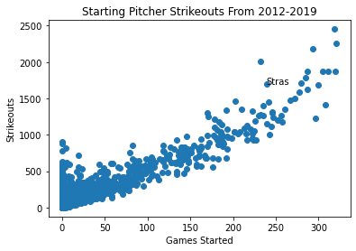

```python
strasburg_era = pitching_data[(pitching_data['yearID'] > 2009) & (pitching_data['yearID'] < 2020)]
pitchers_12_to_19 = strasburg_era.groupby('playerID')
pitchers_12_to_19 = pitchers_12_to_19.sum()
fig, ax = plt.subplots()
ax.scatter(pitchers_12_to_19['GS'], pitchers_12_to_19['SO'])
ax.set_xlabel("Games Started")
ax.set_ylabel("Strikeouts")
ax.set_title("Starting Pitcher Strikeouts From 2012-2019")
ax.annotate('Stras', (pitchers_12_to_19.loc['strasst01']['GS'],pitchers_12_to_19.loc['strasst01']['SO']))
pitchers_12_to_19[pitchers_12_to_19['SO'] >= pitchers_12_to_19.loc['strasst01']['SO']].sort_values(by=['GS'])[['GS','SO']]
```

Another simple and common measure of pitcher success is ERA, earned run average, where a lower number is better. It is calculated as so, (earned runs/innings pitching)*9.

This all begs the question though, if he was so dominant, why didn't he play more. [Injuries](https://www.washingtontimes.com/news/2021/jun/3/timeline-stephen-strasburgs-ample-trips-injured-li/). He missed time in 2011, 2015, 2016, and 2018.

| playerID | GS | ERA |
| --- | --- | --- |
| bumgama01 | 285 | 3.137255 |
| kershcl01 | 293 | 2.313126 |
| scherma01 | 319 | 3.122597 |
| strasst01 | 239 | 3.165431 |
| verlaju01 | 321 | 3.096639 |

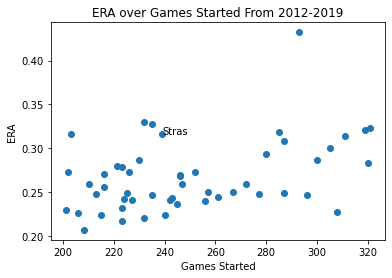

```python
pitchers_12_to_19['ERA'] = 9*(pitchers_12_to_19['ER']/(pitchers_12_to_19['IPouts']/3))
fig, ax = plt.subplots()
ax.scatter(pitchers_12_to_19[pitchers_12_to_19['GS'] > 200]['GS'], 1/pitchers_12_to_19[pitchers_12_to_19['GS'] > 200]['ERA'])
ax.set_xlabel('Games Started')
ax.set_ylabel('ERA')
ax.set_title('ERA over Games Started From 2012-2019')
ax.annotate('Stras', (pitchers_12_to_19.loc['strasst01']['GS'],1/pitchers_12_to_19.loc['strasst01']['ERA']))
pitchers_12_to_19[(pitchers_12_to_19['ERA'] <= pitchers_12_to_19.loc['strasst01']['ERA']) & (pitchers_12_to_19['GS'] >= pitchers_12_to_19.loc['strasst01']['GS'])][['GS','ERA']]
```

## Part 4: Postseason Hero

The culmination of all of Strasburg's great work came in 2019, and especially in the playoffs.

```python
pitching_post = pd.read_csv('PitchingPost.csv')
modern_pitch_post = pitching_post[pitching_post['yearID'] > 1919]
player_year_combo = modern_pitch_post.groupby(['playerID', 'yearID']).sum()
player_year_combo[player_year_combo['W'] > 4]
```

| playerID | yearID | W | L | G | GS | CG | SHO | SV | IPouts | H | ER | ... | IBB | WP | HBP | BK | BFP | GF | R | SH | SF | GIDP |
| --- | --- | --- | --- | --- | --- | --- | --- | --- | --- | --- | --- | --- | --- | --- | --- | --- | --- | --- | --- | --- | --- | --- |
| johnsra05 | 2001 | 5 | 1 | 6 | 5 | 2 | 2 | 0 | 124 | 25 | 7 | ... | 0.0 | 0.0 | 0.0 | 0.0 | 156.0 | 1 | 7 | 1.0 | 1.0 | 3.0 |
| rodrifr03 | 2002 | 5 | 1 | 11 | 0 | 0 | 0 | 0 | 56 | 10 | 4 | ... | 0.0 | 3.0 | 0.0 | 0.0 | 70.0 | 1 | 5 | 0.0 | 1.0 | 0.0 |
| strasst01 | 2019 | 5 | 0 | 6 | 5 | 0 | 0 | 0 | 109 | 30 | 8 | ... | 1.0 | 1.0 | 0.0 | 0.0 | 142.0 | 0 | 9 | 0.0 | 2.0 | 2.0 |

3 rows × 25 columns

Below we have ploted individual pithcer postseason performances where we compare games started verseus strikeouts. We can clearly see that out of pitchers who made 5 starts in a single postseason, Strasburg has the most strikeouts. In postseason history, there is only one pitcher to have struck out more batters than Strasburg. So it should come as no surprise that when the Nats made their [fantastic run to win the 2019 World Series](https://www.washingtonpost.com/sports/nationals/nats-postseason-upset-run-was-the-greatest-in-mlb-history-with-moments-well-never-forget/2019/10/31/ebe71472-fbff-11e9-8190-6be4deb56e01_story.html), Strasburg won the World Series MVP.

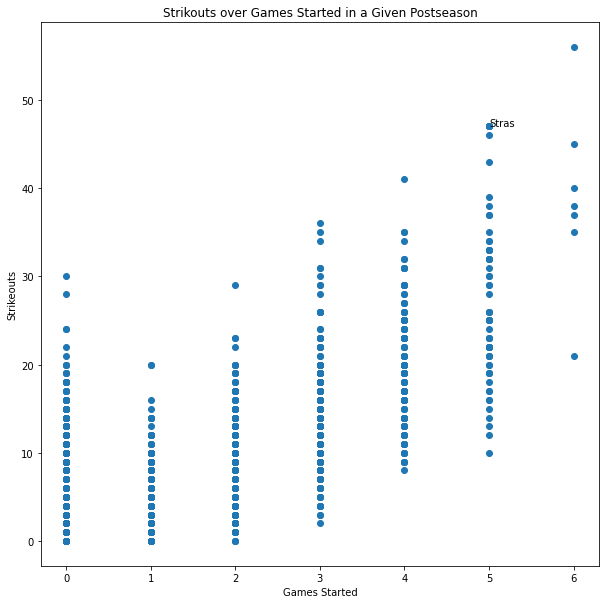

```python
fig, ax = plt.subplots(figsize=(10,10))
ax.scatter(player_year_combo['GS'], player_year_combo['SO'])
ax.set_xlabel('Games Started')
ax.set_ylabel('Strikeouts')
ax.set_title('Strikouts over Games Started in a Given Postseason')
ax.annotate('Stras', (player_year_combo.loc['strasst01', 2019]['GS'],player_year_combo.loc['strasst01', 2019]['SO']))
```

## Part 5: Ouch

Following his World Series MVP, Strasburg was awarded with the a 7-year $245 million contract. It's $35 annual average value was the largest for any pitcher at the time of signing.

Unfortunately for Nats fans, and even more so for Strasburg, the signing is on pace to one of the [worst in league history](https://www.washingtontimes.com/news/2022/jun/20/stephen-strasburg-climbing-list-worst-dc-sports-co/). The old foe that bit him earlier in his carreer, returned with a vegence. He has been injured for much of the past three seasons, and the few oportunities he's had resulted in poor showings.

We begin by reading in MLB salaries from 2019-2021 seasons. Funny enough, Strasburg's data was missing, so I had to manually add it.

```python
salaries = pd.read_csv('mlbSalaries.csv')
salaries[(salaries['name'] == 'Stephen Strasburg')]
tmp = pd.DataFrame({'year':[2020,2021], 'team':['washington-nationals','washington-nationals'], 'name': ['Stephen Strasburg', 'Stephen Strasburg'],
       'salary':[35000000,35000000], 'playerID':[544931,544931]})
salaries = salaries.append(tmp, ignore_index=True)
salaries.tail()
```

|  | year | team | name | salary | playerID |
| --- | --- | --- | --- | --- | --- |
| 2337 | 2021 | washington-nationals | Andres Machado | 291365 | 600921 |
| 2338 | 2021 | washington-nationals | Alcides Escobar | 282164 | 444876 |
| 2339 | 2021 | washington-nationals | Jakson Reetz | 260695 | 0 |
| 2340 | 2020 | washington-nationals | Stephen Strasburg | 35000000 | 544931 |
| 2341 | 2021 | washington-nationals | Stephen Strasburg | 35000000 | 544931 |

The next step is to filter our players who made less that $15 million a season. This is to include only players who have signed tremendoulsy large contracts, those of at least in the ballpark of Strasburg. To add processing later, I drop rows where the player name is incomplete and only contains the last name.

```python
import re
big_salaries = salaries[salaries['salary'] > 15000000]
big_salaries['name'].unique()
big_salaries = big_salaries.set_index('name')
big_salaries = big_salaries.drop('Shin')
big_salaries = big_salaries.drop('Wei')
big_salaries = big_salaries.drop('Hyun')
big_salaries = big_salaries.drop('Martinez')
big_salaries = big_salaries.drop('Pollock')
big_salaries = big_salaries.drop('Happ')
```

The table below contains the name of every player to appear in the major leagues. Since the Salary table comes from a different source, I must extract the playerID from the table below in order to get the player's in big_salaries stats

```python
people = pd.read_csv('People.csv')
people.head()
```

|  | playerID | birthYear | birthMonth | birthDay | birthCountry | birthState | birthCity | deathYear | deathMonth | deathDay | ... | nameLast | nameGiven | weight | height | bats | throws | debut | finalGame | retroID | bbrefID |
| --- | --- | --- | --- | --- | --- | --- | --- | --- | --- | --- | --- | --- | --- | --- | --- | --- | --- | --- | --- | --- | --- |
| 0 | aardsda01 | 1981.0 | 12.0 | 27.0 | USA | CO | Denver | NaN | NaN | NaN | ... | Aardsma | David Allan | 215.0 | 75.0 | R | R | 2004-04-06 | 2015-08-23 | aardd001 | aardsda01 |
| 1 | aaronha01 | 1934.0 | 2.0 | 5.0 | USA | AL | Mobile | 2021.0 | 1.0 | 22.0 | ... | Aaron | Henry Louis | 180.0 | 72.0 | R | R | 1954-04-13 | 1976-10-03 | aaroh101 | aaronha01 |
| 2 | aaronto01 | 1939.0 | 8.0 | 5.0 | USA | AL | Mobile | 1984.0 | 8.0 | 16.0 | ... | Aaron | Tommie Lee | 190.0 | 75.0 | R | R | 1962-04-10 | 1971-09-26 | aarot101 | aaronto01 |
| 3 | aasedo01 | 1954.0 | 9.0 | 8.0 | USA | CA | Orange | NaN | NaN | NaN | ... | Aase | Donald William | 190.0 | 75.0 | R | R | 1977-07-26 | 1990-10-03 | aased001 | aasedo01 |
| 4 | abadan01 | 1972.0 | 8.0 | 25.0 | USA | FL | Palm Beach | NaN | NaN | NaN | ... | Abad | Fausto Andres | 184.0 | 73.0 | L | L | 2001-09-10 | 2006-04-13 | abada001 | abadan01 |

5 rows × 24 columns

I write a function that will return a list containing the playerIDs corresponding to the remaining players in big_salaries.

This is done by using a regular expression to extract the player's first and last name from the big_salaries table. The next step is to pull the playerID from the people table using our regular expression matches. Finally, we add the playerID column.

```python
import re
def get_player_ID(player_names):
    player_ID = []
    for player in player_names:
        name = re.findall('\w+', player)
        player_ID.append(people[(people['nameFirst'] == name[0]) & (people['nameLast'] == name[1])]['playerID'].iloc[0])
    return player_ID
big_salaries['playerID'] = get_player_ID(big_salaries.index)
big_salaries
```

| name | year | team | salary | playerID |
| --- | --- | --- | --- | --- |
| Josh Donaldson | 2019 | atlanta-braves | 23000000 | donaljo02 |
| Freddie Freeman | 2019 | atlanta-braves | 21409375 | freemfr01 |
| Freddie Freeman | 2021 | atlanta-braves | 22359375 | freemfr01 |
| Chris Davis | 2019 | baltimore-orioles | 21065362 | davisch02 |
| David Price | 2019 | boston-red-sox | 31000000 | priceda01 |
| ... | ... | ... | ... | ... |
| Max Scherzer | 2020 | washington-nationals | 17801286 | scherma01 |
| Max Scherzer | 2021 | washington-nationals | 34503480 | scherma01 |
| Patrick Corbin | 2021 | washington-nationals | 24416666 | corbipa01 |
| Stephen Strasburg | 2020 | washington-nationals | 35000000 | strasst01 |
| Stephen Strasburg | 2021 | washington-nationals | 35000000 | strasst01 |

106 rows × 4 columns

Now, we drop non-pitchers from our big_salaries table. This is initially done by checking if a given playerID is in the pitching_data table. If not, we remove it from player salaries. A quirk is that on occasion, position players(non pitchers) pitch. This usually happends when their team is loosing by a lot and doesn't want to waste other pitchers arms. You'll just have to trust me on this one, but I skimmed through the list of remaining players in big_salaries, and dropped those who were not pitchers.

```python
for index, row in big_salaries.iterrows():
    if row['playerID'] not in pitching_data['playerID'].unique() and index in big_salaries.index:
        big_salaries = big_salaries.drop(index)
big_salaries = big_salaries.drop('Justin Turner')
big_salaries = big_salaries.drop('Anthony Rizzo')
big_salaries = big_salaries.drop('Alex Gordon')
big_salaries = big_salaries.drop('Matt Carpenter')
big_salaries = big_salaries.drop('Ryan Braun')
big_salaries = big_salaries.drop('Chris Davis')
```

The next step is to get playing data that corresponds to pitchers who make more than $15 a year. This is done by merging our big_salaries table with our pitching data, using the playerIDs found in both tables. We then restrict the years to be 2020 onward, and make sure that each pitchers on the graph has actaully started a game (relief pitchers come in once the starting pitcher is either tired or is struggling).

And the result, well he's not where we've gotten used to seeing him, at the top right of the graph. This image shows the disapointment that has been his first 3 years under contract.

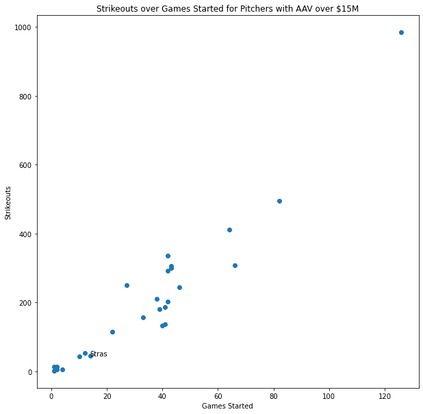

```python
thing = pd.merge(big_salaries, pitching_data, how="left", on="playerID")
thing = thing[(thing['yearID'] >= 2020) & (thing['GS'] > 0)]
thing = thing.groupby('playerID').sum()
fig, ax = plt.subplots(figsize=(10,10))
ax.scatter(thing['GS'], thing['SO'])
ax.set_xlabel('Games Started')
ax.set_ylabel('Strikeouts')
ax.set_title('Strikeouts over Games Started for Pitchers with AAV over $15M')
ax.annotate("Stras", (thing.loc['strasst01']['GS'], thing.loc['strasst01']['SO']))
```

## What's Next?

Despite these setbacks, [Strasburg has been working his tail off](https://www.msn.com/en-gb/sport/mlb/washington-nationals-2023-rotation-stephen-strasburg-talk-at-winter-meetings/ar-AA15boXW) to make a full recovery and attain the hights he had reached just 3 years ago. There are still 4 years left on his deal, and plenty of time to write happy ending to the tale of a man who brought Washington D.C. baseball fans so much joy, and eventually a title, the city's first in 95 years.